# AUTOMATIC TICKET ASSIGNMENT-Approach 1

## AIML Online Capstone - AUTOMATIC TICKET ASSIGNMENT

**Ticket Assignment Project**

One of the key activities of any IT function is to “Keep the lights on” to sure there is no impact to the Business operations. IT leverages Incident Management process to achieve the above Objective. An incident is something that is unplanned interruption to an IT service orreduction in the quality of an IT service that affects the Users and the Business.

**Project Description :**

In this project, the goal is to build a classifier that can classify the tickets by analyzing text.

*Approach 1 : Using classification models, we would be classifying the tickets by considering 500 rows from GRP_0 and the remaining differently sized groups are sampled 350 each. Using TF-IDF Vectorizer,Bi-gram & Chi-square models on the features & there are some KEYwords duplicated across the groups.Keeping such KEYwords only in the groups , where it appears maximum number of times*

**Import necessary libraries**

```python
nltk.download('punkt')
nltk.download('wordnet')
!pip install  fasttext
!pip install wordcloud
!pip install langdetect
!pip install googletrans
!pip install langdetect

import pandas as pd
import matplotlib.pyplot as plt
import seaborn as sns
import numpy as np
import warnings
warnings.filterwarnings('ignore')
import re
import nltk
from nltk.corpus import stopwords
from bs4 import BeautifulSoup
import unicodedata
import googletrans
from googletrans import Translator
from sklearn.linear_model import LogisticRegression
from sklearn.naive_bayes import MultinomialNB
from sklearn.multiclass import OneVsRestClassifier
from sklearn.model_selection import cross_val_score
from sklearn import metrics
from sklearn.metrics import classification_report
from sklearn.metrics import confusion_matrix
from sklearn.model_selection import GridSearchCV
from sklearn.pipeline import make_pipeline
from sklearn.pipeline import Pipeline
from sklearn.metrics import accuracy_score
from sklearn.metrics import confusion_matrix,classification_report
from sklearn.metrics import accuracy_score, f1_score,precision_score,recall_score,classification_report,confusion_matrix,roc_curve,roc_auc_score,auc
```

```python
#Load the contents of zip file
from google.colab import drive
drive.mount('/content/drive')
```

```python
datset_path="/content/drive/My Drive/"
datset_path
```

```
'/content/drive/My Drive/'
```

### Exploratory Data Analysis

```python
# Read the data using pandas read_excel
DF1=pd.read_excel(datset_path+"input_data.xlsx")
```

```python
#Shape of the data
print("Rows and columns in the dataset",DF1.shape)
```

```
Rows and columns in the dataset (8500, 4)
```

```python
#Displaying some column values
DF1.sample(5)
```

|  | Short description | Description | Caller | Assignment group |
| --- | --- | --- | --- | --- |
| 2281 | not able to make outbound calls from siemens p... | not able to make outbound calls from siemens p... | zmgsfner caltmgoe | GRP_37 |
| 1971 | HostName_1015:volume: c:\ is over 85% space co... | HostName_1015:volume: c:\ is over 85% space co... | oldrctiu bxurpsyi | GRP_12 |
| 4095 | job Job_1321 failed in job_scheduler at: 09/17... | received from: monitoring_tool@company.com\r\n... | bpctwhsn kzqsbmtp | GRP_9 |
| 5621 | ticket update on inplant_856223 | ticket update on inplant_856223 | fumkcsji sarmtlhy | GRP_0 |
| 7233 | erp down , internet down in usa pa location | erp down , internet down in usa pa location .\... | mknoeicg aziptqvu | GRP_0 |

```python
#Checking datatype
DF1.info() # all columns contanins object/string datatype
```

```
<class 'pandas.core.frame.DataFrame'>
RangeIndex: 8500 entries, 0 to 8499
Data columns (total 4 columns):
 #   Column             Non-Null Count  Dtype
---  ------             --------------  -----
 0   Short description  8492 non-null   object
 1   Description        8499 non-null   object
 2   Caller             8500 non-null   object
 3   Assignment group   8500 non-null   object
dtypes: object(4)
memory usage: 265.8+ KB
```

```python
# Checking Missing values
null_data = DF1[DF1.isnull().any(axis=1)]# #There are missing values- Under 'Short decription' and 'Description' columns
null_data
```

|  | Short description | Description | Caller | Assignment group |
| --- | --- | --- | --- | --- |
| 2604 | NaN | \r\n\r\nreceived from: ohdrnswl.rezuibdt@gmail... | ohdrnswl rezuibdt | GRP_34 |
| 3383 | NaN | \r\n-connected to the user system using teamvi... | qftpazns fxpnytmk | GRP_0 |
| 3906 | NaN | -user unable tologin to vpn.\r\n-connected to... | awpcmsey ctdiuqwe | GRP_0 |
| 3910 | NaN | -user unable tologin to vpn.\r\n-connected to... | rhwsmefo tvphyura | GRP_0 |
| 3915 | NaN | -user unable tologin to vpn.\r\n-connected to... | hxripljo efzounig | GRP_0 |
| 3921 | NaN | -user unable tologin to vpn.\r\n-connected to... | cziadygo veiosxby | GRP_0 |
| 3924 | NaN | name:wvqgbdhm fwchqjor\nlanguage:\nbrowser:mic... | wvqgbdhm fwchqjor | GRP_0 |
| 4341 | NaN | \r\n\r\nreceived from: eqmuniov.ehxkcbgj@gmail... | eqmuniov ehxkcbgj | GRP_0 |
| 4395 | i am locked out of skype | NaN | viyglzfo ajtfzpkb | GRP_0 |

```python
DF1.describe().T # From the "short description" column, the top most contributing problem description is "Password reset"
```

|  | count | unique | top | freq |
| --- | --- | --- | --- | --- |
| Short description | 8492 | 7481 | password reset | 38 |
| Description | 8499 | 7817 | the | 56 |
| Caller | 8500 | 2950 | bpctwhsn kzqsbmtp | 810 |
| Assignment group | 8500 | 74 | GRP_0 | 3976 |

```python
## Cheack a few samples of descriptions & its Short Description
i=3
for i in range(3):
    print('Short Description:', DF1['Short description'][i])
    print( 'Description:', DF1['Description'][i])
    print('**************************************************************')
```

```
Short Description: login issue
Description: -verified user details.(employee# & manager name)
-checked the user name in ad and reset the password.
-advised the user to login and check.
-caller confirmed that he was able to login.
-issue resolved.
Short Description: outlook
Description:

received from: hmjdrvpb.komuaywn@gmail.com

hello team,

my meetings/skype meetings etc are not appearing in my outlook calendar, can somebody please advise how to correct this?

kind
Short Description: cant log in to vpn
Description:

received from: eylqgodm.ybqkwiam@gmail.com

hi

i cannot log on to vpn

best
```

```python
## Checking if any caller raised ticket in multiple groups
# displays Top 5 callers in each assignment group
top_n = 5
s = DF1['Caller'].groupby(DF1['Assignment group']).value_counts()
caller_grp = pd.DataFrame(s.groupby(level=0).nlargest(top_n).reset_index(level=0, drop=True))
caller_grp.head(8)
```

| Assignment group | Caller | Caller |
| --- | --- | --- |
| GRP_0 | fumkcsji sarmtlhy | 132 |
|  | rbozivdq gmlhrtvp | 86 |
|  | olckhmvx pcqobjnd | 54 |
|  | efbwiadp dicafxhv | 45 |
|  | mfeyouli ndobtzpw | 13 |
| GRP_1 | bpctwhsn kzqsbmtp | 6 |
|  | jloygrwh acvztedi | 4 |
|  | jyoqwxhz clhxsoqy | 3 |

```python
## Checking if any caller raised ticket in multiple groups
mul_caller = caller_grp[caller_grp.Caller.duplicated()]
uni_mul_caller = [idx[1] for idx in mul_caller.index[mul_caller.Caller.unique()]]
print(f'\033[1mFollowing {len(uni_mul_caller)} callers happen to raise tickets for multiple groups:\033[0m\n')
print(uni_mul_caller)

mul_caller
# 15 callers raised tickets for multiple groups # Since there are Callers who raised tickers in multiple group
#lets ignore callers column as it doesnt help much to locate target
```

```
Following 15 callers happen to raise tickets for multiple groups:

['hlrmufzx qcdzierm', 'fbgetczn jlsvxura', 'gnasmtvx cwxtsvkm', 'ihfkwzjd erbxoyqk', 'tqfnalpj qyoscnge', 'fmqubnvs kcxpeyiv', 'tghrloks jbgcvlmf', 'jwqyxbzs adpvilqu', 'nuhfwplj ojcwxser', 'oldrctiu bxurpsyi', 'vlymsnej whlqxcst', 'dkmcfreg anwmfvlg', 'bpctwhsn kzqsbmtp', 'spxqmiry zpwgoqju', 'oban…
```

| Assignment group | Caller | Caller |
| --- | --- | --- |
| GRP_1 | spxqmiry zpwgoqju | 3 |
| GRP_10 | ihfkwzjd erbxoyqk | 6 |
|  | gnasmtvx cwxtsvkm | 3 |
|  | hlrmufzx qcdzierm | 3 |
| GRP_11 | tghrloks jbgcvlmf | 2 |
| ... | ... | ... |
| GRP_73 | kcnosyae zlpmfxgs | 1 |
| GRP_8 | ZkBogxib QsEJzdZO | 54 |
| GRP_9 | ctzykflo evzbhgru | 3 |
|  | sholvcmf bjtpomrl | 3 |
|  | urhpnlaf agmsfqil | 3 |

281 rows × 1 columns

```python
DF1['Assignment group'].nunique()# 74 target class found
```

```
74
```

#### Visualization

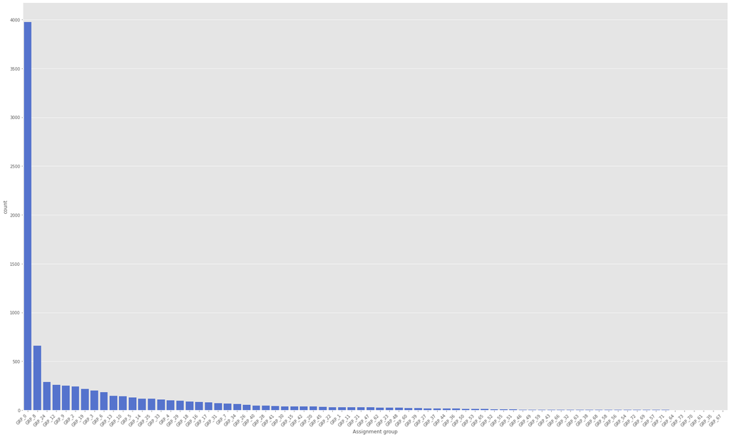

```python
# visualize the count of incidents per assignment group
import seaborn as sns
import matplotlib.pyplot as plt
import warnings
# import pandas.util.testing as tm

plt.style.use('ggplot')
%matplotlib inline

descending_order = DF1['Assignment group'].value_counts().sort_values(ascending=False).index
plt.subplots(figsize=(25,15))
#added code for x label rotate
ax=sns.countplot(x='Assignment group', data=DF1, color='royalblue',order=descending_order)
ax.set_xticklabels(ax.get_xticklabels(), rotation=45, ha="right")
plt.tight_layout()
plt.show()
```

```python
# Incidents Percentage per Assignment group # Around 46% of the data exist in GRP_0
df_inc = DF1['Assignment group'].value_counts().reset_index()
df_inc['percentage'] = (df_inc['Assignment group']/df_inc['Assignment group'].sum())*100
df_inc.head()
```

|  | index | Assignment group | percentage |
| --- | --- | --- | --- |
| 0 | GRP_0 | 3976 | 46.776471 |
| 1 | GRP_8 | 661 | 7.776471 |
| 2 | GRP_24 | 289 | 3.400000 |
| 3 | GRP_12 | 257 | 3.023529 |
| 4 | GRP_9 | 252 | 2.964706 |

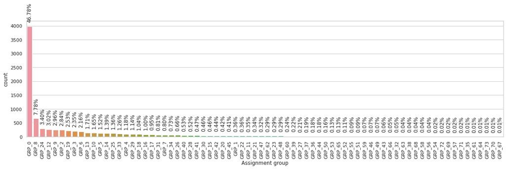

```python
# Plot to visualize the percentage data distribution across different groups
sns.set(style="whitegrid")
plt.figure(figsize=(20,5))
ax = sns.countplot(x="Assignment group", data=DF1, order=DF1["Assignment group"].value_counts().index)
ax.set_xticklabels(ax.get_xticklabels(), rotation=90)
for p in ax.patches:
  ax.annotate(str(format(p.get_height()/len(DF1.index)*100, '.2f')+"%"), (p.get_x() + p.get_width() / 2., p.get_height()), ha = 'center', va = 'bottom', rotation=90, xytext = (0, 10), textcoords = 'offset points')
```

```python
#Distribution of tickets counts in various bins
df_bins = pd.DataFrame(columns=['Description','Ticket Count'])
one_ticket = {'Description':'1 ticket','Ticket Count':len(df_inc[df_inc['Assignment group'] < 2])}
_2_5_ticket = {'Description':'2-5 ticket',
              'Ticket Count':len(df_inc[(df_inc['Assignment group'] > 1)& (df_inc['Assignment group'] < 6) ])}
_10_ticket = {'Description':' 6-10 ticket',
              'Ticket Count':len(df_inc[(df_inc['Assignment group'] > 5)& (df_inc['Assignment group'] < 11)])}
_10_20_ticket = {'Description':' 11-20 ticket',
              'Ticket Count':len(df_inc[(df_inc['Assignment group'] > 10)& (df_inc['Assignment group'] < 21)])}
_20_50_ticket = {'Description':' 21-50 ticket',
              'Ticket Count':len(df_inc[(df_inc['Assignment group'] > 20)& (df_inc['Assignment group'] < 51)])}
_51_100_ticket = {'Description':' 51-100 ticket',
              'Ticket Count':len(df_inc[(df_inc['Assignment group'] > 50)& (df_inc['Assignment group'] < 101)])}
_100_ticket = {'Description':' >100 ticket',
              'Ticket Count':len(df_inc[(df_inc['Assignment group'] > 100)])}
#append row to the dataframe
df_bins = df_bins.append([one_ticket,_2_5_ticket,_10_ticket,
                          _10_20_ticket,_20_50_ticket,_51_100_ticket,_100_ticket], ignore_index=True)

df_bins
```

|  | Description | Ticket Count |
| --- | --- | --- |
| 0 | 1 ticket | 6 |
| 1 | 2-5 ticket | 13 |
| 2 | 6-10 ticket | 6 |
| 3 | 11-20 ticket | 9 |
| 4 | 21-50 ticket | 16 |
| 5 | 51-100 ticket | 9 |
| 6 | >100 ticket | 15 |

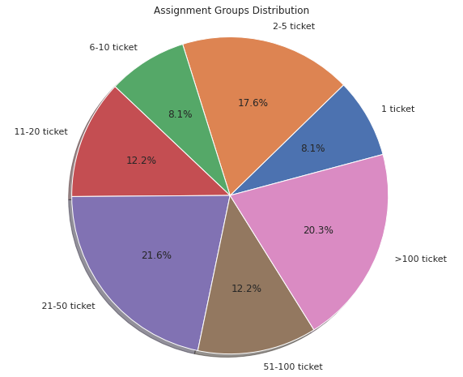

```python
plt.figure(figsize=(10, 8))
plt.pie(df_bins['Ticket Count'],labels=df_bins['Description'],autopct='%1.1f%%', startangle=15, shadow = True);
plt.title('Assignment Groups Distribution')
plt.axis('equal');
```

#### We see that there are 6 Assignment Group’s for which just have 1 ticket in the dataset.

#### There are 15 Assignment group’s which have more than 100 tickets.

#### Only 20% of the Assignment groups have greater than 100 tickets.

```
   Assignment group   text_len
                          mean
0             GRP_0  18.287223
1             GRP_1  27.838710
2            GRP_10  26.442857
3            GRP_11  46.200000
4            GRP_12  38.361868
..              ...        ...
69           GRP_71  36.000000
70           GRP_72   4.000000
71           GRP_73  55.000000
72            GRP_8  37.804841
73            GRP_9  20.857143

[74 rows x 2 columns]

The maximum number of words in the dataset is =  1625
The minimum number of words in the dataset is =  1
The average number of words in the dataset is =  27
The median of number of words in the dataset is =  11
50% of the dataset have number of words that lies between  6 and 28
```

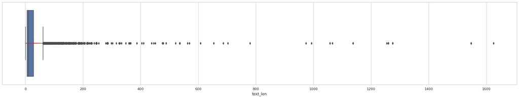

```python
# Find the mean of the number of words across different Assignment groups
DF1_length=DF1
DF1_length['text_len']=DF1_length['Description'].str.split().map(lambda x: len(str(x).split(" ")))
plt.figure(figsize=(30,5));
sns.boxplot(DF1_length['text_len'],showmeans=True,meanprops={"marker": "+",
                      "markeredgecolor": "red",
                       "markersize": "40"});

print(DF1_length.groupby(['Assignment group']).agg(['mean']).reset_index())
print()
print("The maximum number of words in the dataset is = ",DF1_length['text_len'].max())
print("The minimum number of words in the dataset is = ",DF1_length['text_len'].min())
print("The average number of words in the dataset is = ",round(DF1_length['text_len'].mean()))
print("The median of number of words in the dataset is = ",round(DF1_length['text_len'].median()))

from scipy.stats import iqr
Q1 = np.percentile(DF1_length['text_len'], 25, interpolation = 'midpoint')
Q3 = np.percentile(DF1_length['text_len'], 75, interpolation = 'midpoint')
print("50% of the dataset have number of words that lies between ",round(Q1),"and",round(Q3))
print()
```

#### Word Cloud before data processing

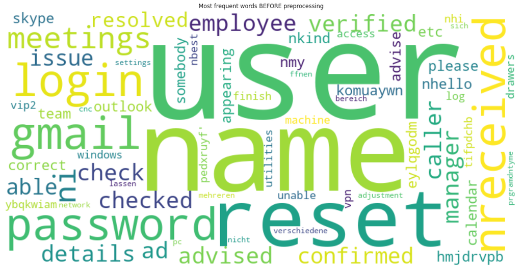

```python
from wordcloud import WordCloud, STOPWORDS, ImageColorGenerator
#word cloud for overall data
stopwords = STOPWORDS

wordcloud = WordCloud(stopwords = stopwords, max_words=500, background_color="white",width=800, height=400).generate(str(DF1['Description'].values))

plt.figure( figsize=(20,10) )
plt.title('Most frequent words BEFORE preprocessing')
plt.imshow(wordcloud,interpolation='bilinear')
plt.axis("off")
plt.show()
```

### Observations:

There are 4 columns and all are string columns and there are totally 8500 rows and there seems to be mising values in Short description and Description columns

There are 74 unique groups to which the received tickets are assigned.

Data is HIGHLY imbalanced with majority of incidents are from Group 0 followed by Group 8 , 24 , 12 , 9 , 2 and so on.There are few classes which just have less 10 incidents pers class and even classed with just 1 or 2 incidents. need to see if we can drop those rows due to the lack of samples representing those classes. They might not be of much help as a predictor

Password reset seems to be highest re-occuring ticket. A specific caller has a very high frequency of raising tickets.

Caller could be an important feature . But Caller column mainly contains the details of the user who raised the incident and the same caller has raised in diffrent tickets in different groups, hence the column is of not much use in our analysis and can be dropped.

Lets consider "Description" column as X feature and clean the description before building model.

Assignment group is our target column with multiple classes. This is a Multiclass Classification problem.

### DATA CLEANING

```python
#Dealing with missing values #Since null count is less, dropping null values
DF1.dropna(inplace=True)
```

```python
# checking data shape after removing missing values# 9 null rows are removed
DF1.shape
```

```
(8491, 5)
```

**Lets clean up the Description column to address the following**

 Remove stopwords

 Convert each character in a sentence to lowercase character.

 Remove HTML Tags

 Remove accented characters, special characters

 Remove stopwords

 Remove extra white spaces

 Remove common words like com, hello,"received from", "team","Advise?","kind" etc

 Stemming was causing invalid words, hence using lemmatizer

 Translation

 Remove text in square brackets,remove links,remove punctuation and remove words containing numbers

 Drop the rows which contians duplicate values in description

 Removing the most frequent word ACROSS assignment groups to have better accuracy

 Finally cleaning blank values afer cleaning

```python
callers=DF1.Caller.unique() # lets remove caller names ALONE from the description.#caller name in email address
#will be removed in upcoming functions below.
for char in callers:
    DF1['Description'] = DF1['Description'].str.replace(char, ' ')
```

```python
callers
```

```
array(['spxjnwir pjlcoqds', 'hmjdrvpb komuaywn', 'eylqgodm ybqkwiam', ...,
       'bjitvswa yrmugfnq', 'oybwdsgx oxyhwrfz', 'kqvbrspl jyzoklfx'],
      dtype=object)
```

```python
DF2=DF1.drop(['Short description','Caller'],axis=1) ##Since the caller column is not useful, we can also drop it
#Also removing "Short description" as Description itself contians the data in it
```

```python
# Remove stopwords
nltk.download('stopwords')
from nltk.corpus import stopwords
stopwords = set(stopwords.words('english'))
DF2['clean_text'] = DF2.Description.apply(lambda x: ' '.join([word for word in x.split() if word not in stopwords]))
```

```python
# CREATING FUNCTIONS TO PREPROCESS DESCRIPTION COLUMN

# Remove EMAIL ADDRESS
def remove_emailaddress(text):
    #Using regex
    pattern = r'[a-zA-Z0-9_.+-]+@[a-zA-Z0-9-]+\.[a-zA-Z0-9-.]{2,4}'
    text = re.sub(pattern, '', text)
    return text

#Remove HTML tags
def strip_html_tags(text):
    soup = BeautifulSoup(text, "html.parser")
    stripped_text = soup.get_text()
    return stripped_text

#Remove accented characters
def remove_accented_chars(text):
    text = unicodedata.normalize('NFKD', text).encode('ascii', 'ignore').decode('utf-8', 'ignore')
    return text

# Remove special characters
def remove_special_characters(text, remove_digits=False):
    #Using regex
    pattern = r'[^a-zA-z0-9\s]' if not remove_digits else r'[^a-zA-z\s]'
    text = re.sub(pattern, '', text)
    return text

#Lemmatization
from nltk.stem import WordNetLemmatizer
def lemmatize_text(text):
    lemmatizer = WordNetLemmatizer()
    return ' '.join([lemmatizer.lemmatize(word) for word in text.split()])

#Remove mail related words
mail_words_list = ['hi','hello','com','gmail','cc','regards','thanks']
def mail_words(text):
    finalTokens = []
    tokens = nltk.word_tokenize(text)
    for w in tokens:
        if (w not in mail_words_list):
            finalTokens.append(w)
    text = " ".join(finalTokens)
    return text

def multiple_spaces(text):
    pattern = r'[\s\s]'
    text = re.sub(pattern, ' ', text)
    return text

def remove_special_characters(text, remove_digits=False):
    #Using regex
    pattern = r'[^a-zA-z0-9\s]' if not remove_digits else r'[^a-zA-z\s]'
    text = re.sub(pattern, ' ', text)
    return text
```

```python
# Building a text normalizer
def normalize_corpus(corpus,remove_emails=True, html_stripping=True, accented_char_removal=True, text_lower_case=True,
                     text_lemmatization=True, special_char_removal=True,
                     stopword_removal=True, remove_digits=True,multi_spaces=True):

    normalized_corpus = []
    # normalize each document in the corpus
    for doc in corpus:
        if remove_emails:
            doc=remove_emailaddress(doc)
        # strip HTML
        if html_stripping:
            doc = strip_html_tags(doc)
        # remove accented characters
        if accented_char_removal:
            doc = remove_accented_chars(doc)
        # lowercase the text
        if text_lower_case:
            doc = doc.lower()
        # remove extra newlines
        doc = re.sub(r'[\r|\n|\r\n]+', ' ',doc)
        # lemmatize text
        if text_lemmatization:
            doc = lemmatize_text(doc)
        #Remove mail related words
        if mail_words:
            doc = mail_words(doc)
        # remove special characters and\or digits
        if special_char_removal:
            # insert spaces between special characters to isolate them
            special_char_pattern = re.compile(r'([{.(-)!}])')
            doc = special_char_pattern.sub(" \\1 ", doc)
            doc = remove_special_characters(doc, remove_digits=remove_digits)
        # remove extra whitespace
        doc = re.sub(' +', ' ', doc)
        #remove multiple spaces
        if multi_spaces:
            doc = multiple_spaces(doc)

        normalized_corpus.append(doc)

    return normalized_corpus
```

```python
DF2['clean_text'] = normalize_corpus(DF2['clean_text']) #cleaning text by calling "normalize_corpus" function
```

```python
# We are removing some common words like "received  from", "team","Advise?","kind" etc
# remove text in square brackets,remove links,remove punctuation and remove words containing numbers
# finanly removing extra spaces
import string
def clean_text(text):
    text=text.replace('email:','')
    text=text.replace('email address:','')
    index1=text.find('from:')
    index2=text.find('\nsddubject:')
    text=text.replace(text[index1:index2],'')
    index3=text.find('[cid:image')
    index4=text.find(']')
    text=text.replace(text[index3:index4],'')
    text=text.replace('subject:','')
    text=text.replace('received from','')
    text=text.replace('this message was sent from an unmonitored email address', '')
    text=text.replace('please do not reply to this message', '')
    text=text.replace('monitoring_tool@company.com','MonitoringTool')
    text=text.replace('select the following link to view the disclaimer in an alternate language','')
    text=text.replace('description problem', '')
    text=text.replace('steps taken far', '')
    text=text.replace('customer job title', '')
    text=text.replace('sales engineer contact', '')
    text=text.replace('description of problem:', '')
    text=text.replace('steps taken so far', '')
    text=text.replace('please do the needful', '')
    text=text.replace('please note that ', '')
    text=text.replace('please find below', '')
    text=text.replace('date and time', '')
    text=text.replace('kindly refer mail', '')
    text=text.replace('name:', '')
    text=text.replace('language:', '')
    text=text.replace('customer number:', '')
    text=text.replace('telephone:', '')
    text=text.replace('summary:', '')
    text=text.replace('sincerely', '')
    text=text.replace('company inc', '')
    text=text.replace('importance:', '')
    text=text.replace('gmail.com', '')
    text=text.replace('company.com', '')
    text=text.replace('microsoftonline.com', '')
    text=text.replace('company.onmicrosoft.com', '')
    text=text.replace('hello', '')
    text=text.replace('hallo', '')
    text=text.replace('hi it team', '')
    text=text.replace('hi team', '')
    text=text.replace('team', '')
    text=text.replace("this" , '')
    text=text.replace('hi ', ' ')
    text=text.replace('best', '')
    text=text.replace('kind', '')
    text=text.replace('regards', '')
    text=text.replace('good morning', '')
    text=text.replace('good noon', '')
    text=text.replace('good afternoon', '')
    text=text.replace('good evening', '')
    text=text.replace('good day', '')
    text=text.replace('please', '')
    text=text.replace('regards', '')
    text=text.replace("somebody" , '')
    text=text.replace("advised" , '')
    text=text.replace("advise" , '')
    text=text.replace("how" , '')

    text = re.sub(r'\S+@\S+', ' ', text)
    custom_punctuation='!"#$%&\'()*+,-./:;<=>?@[\\]^`{|}~'
    text = re.sub(r'\w*\d\w*', ' ', text)
    text = re.sub(r'\[.*?\]', ' ', text)
    text = re.sub(r'https?://\S+|www\.\S+', ' ', text)
    text = re.sub(r'<.*?>+', '', text)
    text = re.sub(r'[%s]' % re.escape(string.punctuation), ' ', text)
    text = re.sub(r'\r\n', ' ', text)
    text = re.sub(r'\n', ' ', text)
    text = re.sub(r'\S+@\S+', ' ', text)
    text=text.replace("  ",' ')
    text=text.replace("   ",' ')
    text=text.replace("    ",' ')

    return text
```

```python
DF2['clean_text'] = DF2['clean_text'].apply(lambda x: clean_text(x))# cleaning text by calling "clean_text" function
```

### Translate

```python
from langdetect import detect

def fn_lan_detect(DF2):
    try:
        return detect(DF2)
    except:
        return 'no'

DF2['language'] = DF2['clean_text'].apply(fn_lan_detect)
```

```python
DF2['language'].value_counts()
```

```
en    5682
af     419
de     411
fr     385
sl     355
no     229
it     160
da     150
sv     137
ca     109
nl     106
ro      74
es      67
pl      47
pt      43
et      27
cy      25
tl      18
so      14
id       9
fi       6
cs       6
lt       4
hu       4
sw       1
hr       1
sq       1
sk       1
Name: language, dtype: int64
```

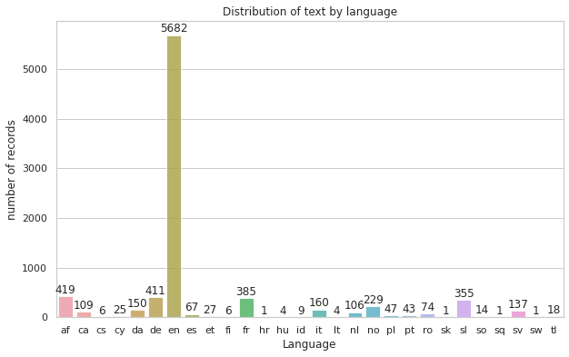

```python
x = DF2["language"].value_counts()
x=x.sort_index()
plt.figure(figsize=(10,6))
ax= sns.barplot(x.index, x.values, alpha=0.8)
plt.title("Distribution of text by language")
plt.ylabel('number of records')
plt.xlabel('Language')
rects = ax.patches
labels = x.values
for rect, label in zip(rects, labels):
    height = rect.get_height()
    ax.text(rect.get_x() + rect.get_width()/2, height + 5, label, ha='center', va='bottom')
plt.show();
```

#### We can see that most of the tickets are in english, followed by tickets in other languages.

#### We need to translate these into english. We will be using google translate package to translate

```python
# Function to translate the text to english.
def fn_translate(df,lang):
    try:
        if lang == 'en':
            return df
        else:
            print(df)
            return translator.translate(df).text
    except:
        return df
```

```python
#Calling the translation function
DF2['clean_text_translated'] = DF2.apply(lambda x: fn_translate(x['clean_text'], x['language']), axis=1)
```

[output not shown]

[output cut: 2754 more lines]

[output not shown]

```python
# lets call data clean functions Once agian to clean translated data
DF2['clean_text_translated'] = normalize_corpus(DF2['clean_text_translated']) # # cleaning text by calling "normalize_corpus" function

DF2['clean_text_translated'] = DF2['clean_text_translated'].apply(lambda x: clean_text(x))# cleaning text by calling "clean_text" function
```

#### WORD CLOUD AFTER PREPROCESSING

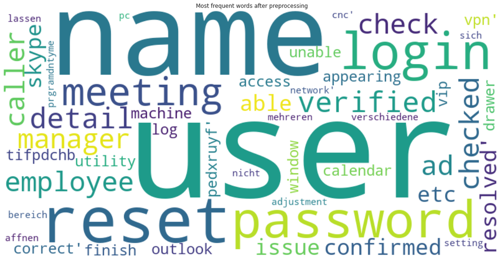

```python
from wordcloud import WordCloud, STOPWORDS, ImageColorGenerator
#word cloud for overall data
stopwords = STOPWORDS

wordcloud = WordCloud(stopwords = stopwords, max_words=500, background_color="white",width=800, height=400).generate(str(DF2['clean_text_translated'].values))

plt.figure( figsize=(20,10) )
plt.title('Most frequent words after preprocessing')
plt.imshow(wordcloud,interpolation='bilinear')
plt.axis("off")
plt.show()
```

### CHECKING NULL VALUES/ BLANK ROWS AFTER PREPROCESSING

```python
# Checking Missing values after translation
DF2.isnull().any()
```

```
Description              False
Assignment group         False
text_len                 False
clean_text               False
language                 False
clean_text_translated    False
dtype: bool
```

```python
print('Dataset rows shape ',DF2.shape[0])
```

```
Dataset rows shape  8491
```

#### Removing rows that contains less than 2 words

```python
DF2['num_words'] = DF2['clean_text_translated'].apply(lambda x: len(x.split()))# create a column to show words count
print('Maximum words count is', DF2['num_words'].max())
print('Mininum words count is', DF2['num_words'].min())
```

```
Maximum words count is 1244
Mininum words count is 0
```

```python
DF2[DF2['num_words']<2] # DISPLAYS rows which have only one word
```

|  | Description | Assignment group | text_len | clean_text | language | clean_text_translated | num_words |
| --- | --- | --- | --- | --- | --- | --- | --- |
| 39 | call for | GRP_0 | 4 | call | it | call | 1 |
| 51 | call for | GRP_0 | 4 | call | it | call | 1 |
| 62 | \r\n\r\nreceived from: lkfzibrx.ljnabpgx@gmail... | GRP_0 | 5 |  | no |  | 0 |
| 229 | call for | GRP_0 | 4 | call | it | call | 1 |
| 415 | complete | GRP_17 | 1 | complete | fr | complete | 1 |
| ... | ... | ... | ... | ... | ... | ... | ... |
| 8092 | the | GRP_17 | 1 |  | no |  | 0 |
| 8093 | the | GRP_17 | 1 |  | no |  | 0 |
| 8168 | the | GRP_17 | 1 |  | no |  | 0 |
| 8222 | no boot : 7350 | GRP_0 | 4 | boot | af | boot | 1 |
| 8477 | \r\n\r\nreceived from: cfzsajbe.lyejkdho@gmail... | GRP_0 | 5 |  | no |  | 0 |

111 rows × 7 columns

```python
DF2 = DF2[DF2['num_words']>1] #As there is no much important feature,dropping the rows that have <2 words
DF2.head()
```

|  | Description | Assignment group | text_len | clean_text | language | clean_text_translated | num_words |
| --- | --- | --- | --- | --- | --- | --- | --- |
| 0 | -verified user details.(employee# & manager na... | GRP_0 | 33 | verified user details employee manager name c... | en | verified user detail employee manager name che... | 21 |
| 1 | \r\n\r\nreceived from: hmjdrvpb.komuaywn@gmail... | GRP_0 | 25 | meetings skype meeting etc appearing outlook ... | en | meeting skype meeting etc appearing outlook ca... | 8 |
| 2 | \r\n\r\nreceived from: eylqgodm.ybqkwiam@gmail... | GRP_0 | 11 | can not log vpn | en | can not log vpn | 4 |
| 3 | unable to access hr_tool page | GRP_0 | 5 | unable access hr tool page | en | unable access hr tool page | 5 |
| 4 | skype error | GRP_0 | 2 | skype error | no | skype error | 2 |

### Dropping duplicates rows, whereever there is duplicate text in description

```python
duplicated_=DF2[DF2.duplicated(['clean_text_translated'])]
duplicated_
```

|  | Description | Assignment group | text_len | clean_text | language | clean_text_translated | num_words |
| --- | --- | --- | --- | --- | --- | --- | --- |
| 15 | ticket update on inplant_874743 | GRP_0 | 4 | ticket update inplant | sv | ticket update inplant | 3 |
| 35 | ticket_no1564677-employment status - new non-e... | GRP_0 | 5 | ticket no employment status new non employee | en | ticket no employment status new non employee | 7 |
| 40 | ticket update - inplant_874615 | GRP_0 | 4 | ticket update inplant | en | ticket update inplant | 3 |
| 59 | received from: monitoring_tool@company.com\r\n... | GRP_8 | 11 | job mm zscr dly merktc failed job scheduler at | en | job mm zscr dly merktc failed job scheduler at | 9 |
| 60 | received from: monitoring_tool@company.com\r\n... | GRP_8 | 11 | job job failed job scheduler at | sl | job job failed job scheduler at | 6 |
| ... | ... | ... | ... | ... | ... | ... | ... |
| 8460 | received from: monitoring_tool@company.com\r\n... | GRP_9 | 11 | abended job job scheduler job | sl | abended job job scheduler job | 5 |
| 8462 | received from: monitoring_tool@company.com\r\n... | GRP_9 | 11 | abended job job scheduler job | sl | abended job job scheduler job | 5 |
| 8466 | received from: monitoring_tool@company.com\r\n... | GRP_8 | 11 | abended job job scheduler bkwin hostname inc | en | abended job job scheduler bkwin hostname inc | 7 |
| 8486 | ticket update on ticket_no0427635 | GRP_0 | 4 | ticket update ticket no | sv | ticket update ticket no | 4 |
| 8489 | account locked | GRP_0 | 2 | account locked | en | account locked | 2 |

1882 rows × 7 columns

```python
DF2[DF2['clean_text_translated']=='account locked'].head(3) # Displays some duplicated sentences
```

|  | Description | Assignment group | text_len | clean_text | language | clean_text_translated | num_words |
| --- | --- | --- | --- | --- | --- | --- | --- |
| 27 | account locked out | GRP_0 | 3 | account locked | en | account locked | 2 |
| 344 | account locked out | GRP_0 | 3 | account locked | en | account locked | 2 |
| 423 | account locked. | GRP_0 | 2 | account locked | en | account locked | 2 |

```python
DF2[DF2['clean_text_translated']=='abended job job scheduler sid cold'].head(3) # Displays some duplicated sentences
# In this case the above keyword duplicated ACROSS multiple groups
```

|  | Description | Assignment group | text_len | clean_text | language | clean_text_translated | num_words |
| --- | --- | --- | --- | --- | --- | --- | --- |
| 7606 | received from: monitoring_tool@company.com\r\n... | GRP_8 | 11 | abended job job scheduler sid cold | en | abended job job scheduler sid cold | 6 |
| 7607 | received from: monitoring_tool@company.com\r\n... | GRP_5 | 11 | abended job job scheduler sid cold | en | abended job job scheduler sid cold | 6 |
| 7609 | received from: monitoring_tool@company.com\r\n... | GRP_8 | 11 | abended job job scheduler sid cold | en | abended job job scheduler sid cold | 6 |

#### As we can see some of the KEYwords are duplicated across the groups.

#### lets keep such words only in the groups , where it appears maximum number of times

```python
DF2[DF2["clean_text_translated"].str.contains("job scheduler")]["Assignment group"].value_counts()
#  keyword "job scheduler" is COMMON across all groups, hence keep the records only in high count group
```

```
GRP_8     418
GRP_9     184
GRP_6     124
GRP_5     113
GRP_10     63
GRP_60     13
GRP_47     12
GRP_45      8
GRP_12      8
GRP_1       7
GRP_13      4
GRP_18      3
GRP_14      3
GRP_29      3
GRP_44      1
GRP_34      1
GRP_57      1
GRP_19      1
Name: Assignment group, dtype: int64
```

```python
# Groups contains keyword "job scheduler"
filter_common_grps_=duplicated_[duplicated_["clean_text_translated"].str.contains("job scheduler")]["Assignment group"].unique()
filter_common_grps_
```

```
array(['GRP_8', 'GRP_9', 'GRP_10', 'GRP_6', 'GRP_5', 'GRP_13', 'GRP_12',
       'GRP_47', 'GRP_29', 'GRP_18', 'GRP_44', 'GRP_14', 'GRP_45',
       'GRP_60', 'GRP_1', 'GRP_57'], dtype=object)
```

```python
# FILTERING descriptions index which contains "job scheduler",except GRP_8
DF2B=DF2[DF2["clean_text_translated"].str.contains("job scheduler")]
DF2BA=DF2B[DF2B['Assignment group']!='GRP_8']
drop_index=DF2BA.index
drop_index # index locations
```

```
Int64Index([  47,   67,   75,   76,   77,   80,   83,   85,   86,   90,
            ...
            8310, 8311, 8317, 8318, 8319, 8321, 8356, 8358, 8460, 8462],
           dtype='int64', length=549)
```

```python
# Removing descriptions which contains "job scheduler",except GRP_8
DF2r=DF2.copy()
DF2r.drop(DF2r.loc[drop_index].index, inplace=True)
```

```python
print("shape of original dataset ",DF2.shape)
print("shape of dataset that needs to be dropped",DF2BA.shape)
print("shape of dataset after dropping",DF2r.shape)
```

```
shape of original dataset  (8380, 7)
shape of dataset that needs to be dropped (549, 7)
shape of dataset after dropping (7831, 7)
```

```python
DF2r[DF2r["clean_text_translated"].str.contains("job scheduler")]["Assignment group"].value_counts()
#  keyword "job scheduler" is COMMON across all groups, hence keep the records only in high count group
```

```
GRP_8    418
Name: Assignment group, dtype: int64
```

```python
# Lets remove duplicated texts
DF3=DF2r.copy()
DF3.drop_duplicates(subset='clean_text_translated',inplace=True)
```

```python
#Reset Index
DF4=DF3.reset_index()
```

```python
# Removing other columns and below columns for model building
DF4 =DF4[['clean_text_translated','Assignment group']]
```

```python
## Checking few CLEANED Description afer preprocessing
i=3
for i in range(15):
    print( 'cleaned text:', DF2['clean_text_translated'][i])
    print('****')
```

```
cleaned text: verified user detail employee manager name checked user name ad reset password user login check caller confirmed able login issue resolved
****
cleaned text: meeting skype meeting etc appearing outlook calendar correct
****
cleaned text: can not log vpn
****
cleaned text: unable access hr tool page
****
cleaned text: skype error
****
cleaned text: unable log engineering tool skype
****
cleaned text: event critical hostname company value mountpoint threshold oracle sid erpdata sr psa d sr psa d data perpsr psa d
****
cleaned text: ticket no employment status new non employee
****
cleaned text: unable disable add in outlook
****
cleaned text: ticket update inplant
****
cleaned text: engineering tool say connected unable submit report
****
cleaned text: hr tool site loading page correctly
****
cleaned text: unable login hr tool sgxqsuojr xwbesorf card
****
cleaned text: user want reset password
****
cleaned text: unable open payslip
****
```